# Módulo 6

Support Vector Machines

Eloy Alvarado Narváez

eloy.alvarado@usm.cl

Universidad Técnica Federico Santa María

Esteban Salgado Valenzuela

Universidad Técnica Federico Santa María

14 de diciembre de 2024

# Support Vector Machines

## Support Vector Machine

- Esta metodología fue desarrollada en lo ’90 por la comunidad de ciencias computacionales.
- Consiste en la generalización de un clasificador llamado clasificador de máximo margen, que destaca por su simpleza, pero que en la práctica es difícil de utilizar debido a que requiere que las clases sean separables por un límite lineal.
- Antes de definir el clasificador de máximo margen, debemos introducir dos conceptos fundamentales:
  - Hiperplano
  - Hiperplano de separación óptimo

## ¿Qué es un Hiperplano?

Un hiperplano en $p$ dimensiones es un subespacio afín plano de dimensión $p - 1$.

- En general, la ecuación de un hiperplano tiene la forma:
  $$\beta_0 + \beta_1 X_1 + \beta_2 X_2 + \dots + \beta_p X_p = 0$$
- En $p = 2$ dimensiones, un hiperplano es una línea.
- Si $\beta_0 = 0$, el hiperplano pasa por el origen; de lo contrario, no.
- El vector $\beta = (\beta_1, \beta_2, \dots, \beta_p)$ se llama vector normal — apunta en una dirección ortogonal a la superficie del hiperplano.

## ¿Qué es un Hiperplano?

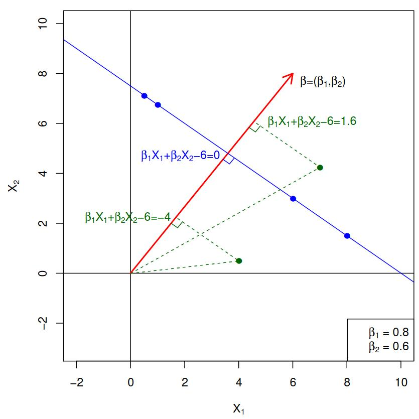

## ¿Qué es un Hiperplano?

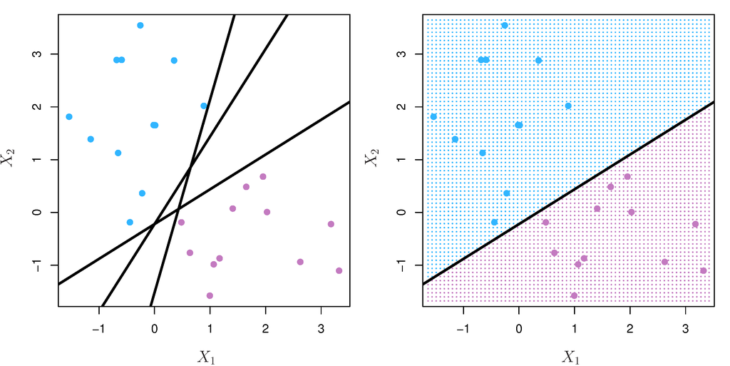

- Si $f(X) = \beta_0 + \beta_1 X_1 + \dots + \beta_p X_p$, entonces $f(X) > 0$ para los puntos en un lado del hiperplano, y $f(X) < 0$ para los puntos en el otro.
- Si codificamos los puntos coloreados como $Y_i = +1$ con azul, por ejemplo, y $Y_i = -1$ con rojo, entonces si $Y_i \cdot f(X_i) > 0$ para todo $i$, $f(X) = 0$ define un hiperplano separador.

## Clasificador de máximo margen

Entre todos los hiperplanos separadores, se busca encontrar aquel que maximice la brecha o margen entre las dos clases.

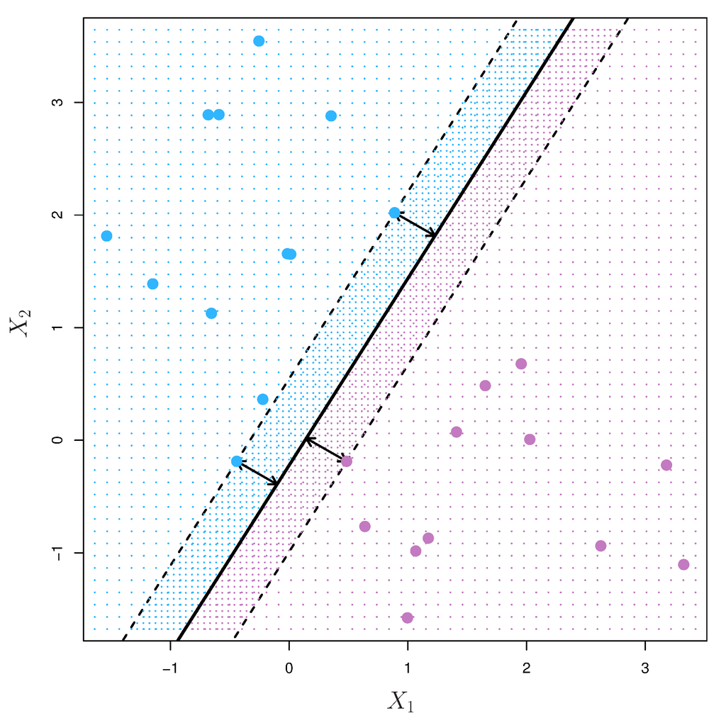

$$\begin{align*}
&\max_{\beta_0,\beta_1,\dots,\beta_p} \quad M\\
&\text{ Sujeto a } \sum_{j=1}^{p} \beta_{j}^{2}=1 \\
&y_i(\beta_0 +\beta_0+\beta_1 x_{i1}+\dots+\beta_p x_{ip})\geq M \\
&\forall i=1,\dots,n
\end{align*}$$

## Datos no separables

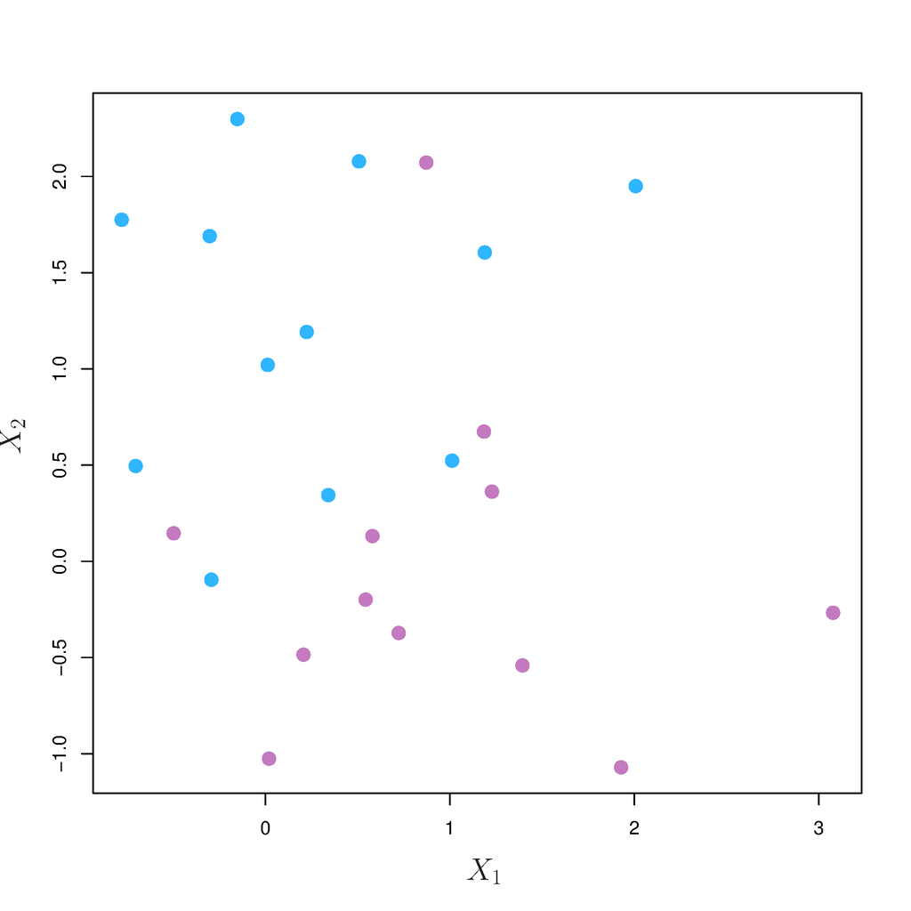

- Los datos de la izquierda [no son separables por una recta lineal].
- Esto es el caso usual, a menos que $N<p$.

## Datos ruidosos/pertubados

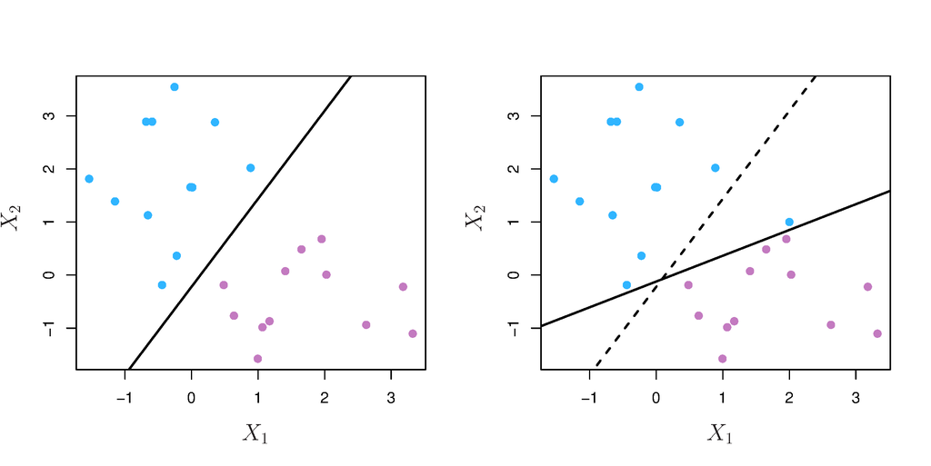

- A veces los datos son separables, pero están perturbados. Esto puede llevar a soluciones no-óptimas para el clasificador de margen máximo.
- El clasificador de vectores de soporte maximiza un margen suave.

## Clasificador de vectores de soporte (*soft margin classifier*)

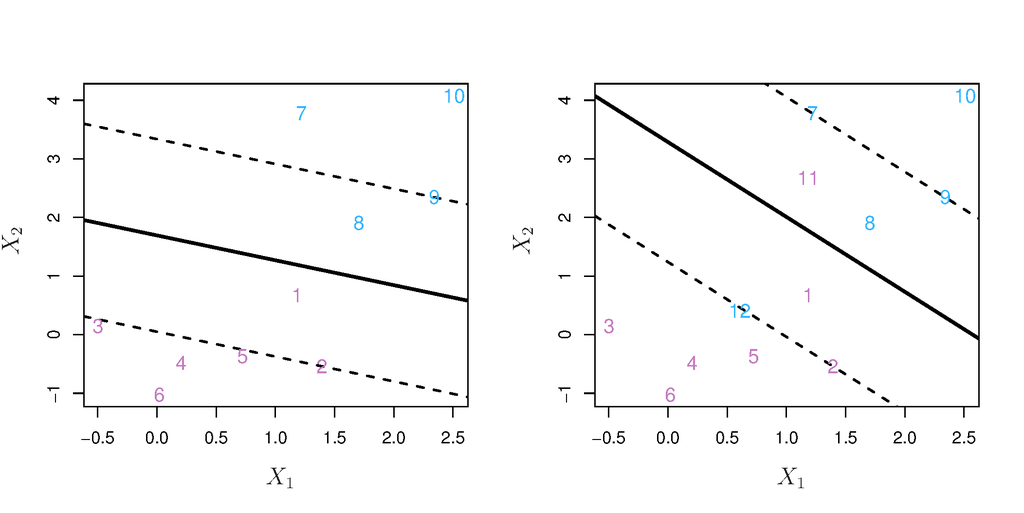

$$\begin{align*}
&\max_{\beta_0,\beta_1,\dots,\beta_p; \epsilon_1,\dots,\epsilon_n} \quad M \quad \quad \text{ Sujeto a } \sum_{j=1}^{p} \beta_{j}^{2}=1 \\
&y_i(\beta_0 +\beta_0+\beta_1 x_{i1} +\beta_2 x_{i2}+\dots+\beta_p x_{ip})\geq M (1-\epsilon_i) \quad \forall i=1,\dots,n \\
&\epsilon_i \geq 0, \sum_{i=1}^{n} \epsilon_i \leq C
\end{align*}$$

## $C$ es un parámetro de regularización

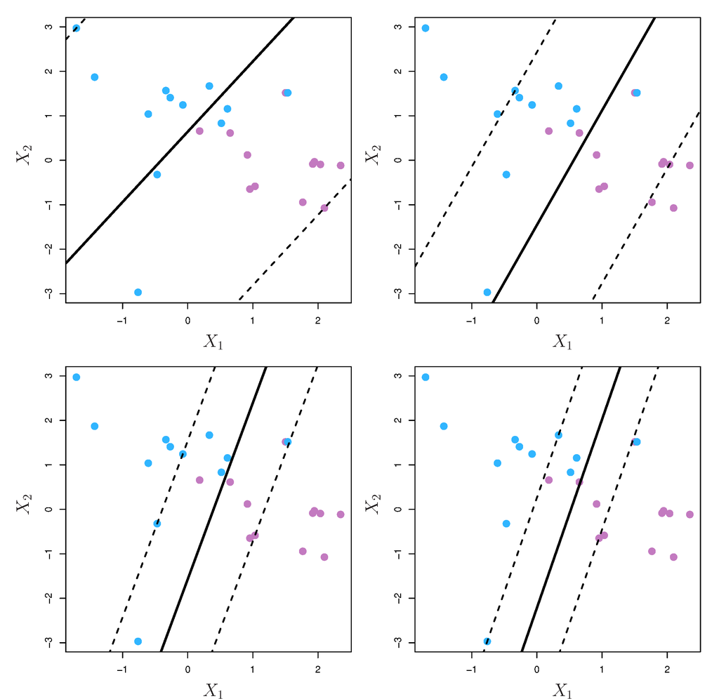

## Una separación lineal puede fallar

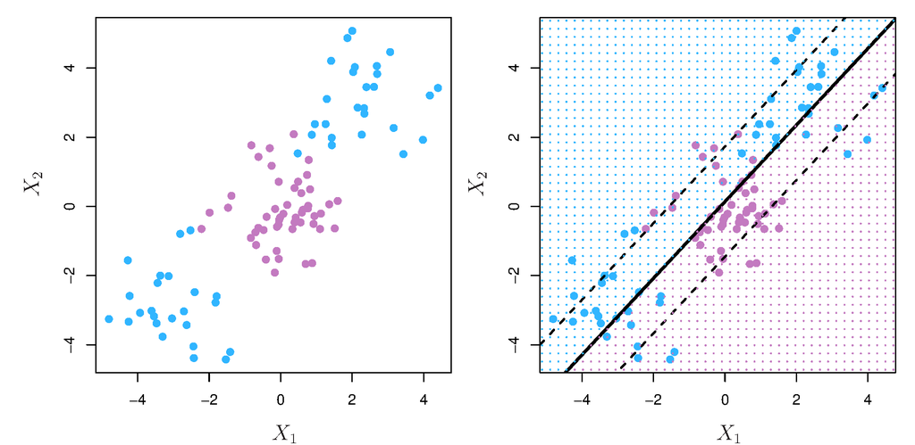

- A veces una separación lineal simplemente no funciona, para ningún valor de $C$.

## Expansión de características

- Ampliar el espacio de características mediante la inclusión de transformaciones; por ejemplo: $X_1^2, X_1^3, X_1 X_2, X_1 X_2^2, \dots$. De este modo, se pasa de un espacio de $p$ dimensiones a un espacio de $M > p$ dimensiones.
- Ajustar un clasificador de vectores de soporte en el espacio ampliado.
- Esto da como resultado fronteras de decisión no lineales en el espacio original.

Supongamos que utilizamos $(X_1, X_2, X_1^2, X_2^2, X_1 X_2)$ en lugar de solo $(X_1, X_2)$. Entonces la frontera de decisión sería de la forma:
$$\beta_0 + \beta_1 X_1 + \beta_2 X_2 + \beta_3 X_1^2 + \beta_4 X_2^2 + \beta_5 X_1 X_2 = 0$$

## Polinomios cúbicos

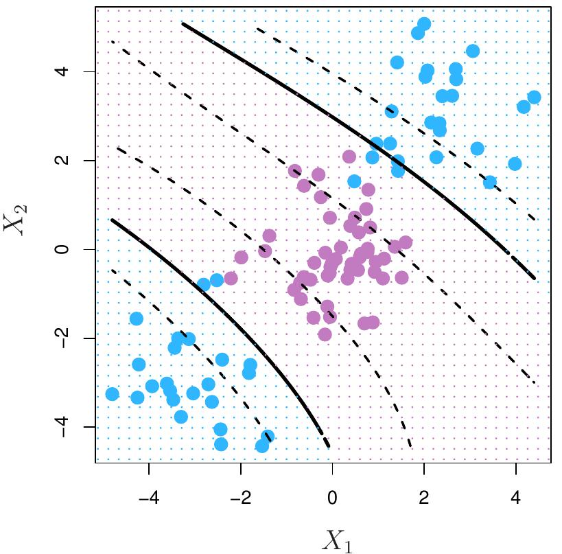

- Aquí utilizamos una expansión de base con polinomios cúbicos.
- Se pasa de 2 variables a 9 características.
- El clasificador de vectores de soporte en el espacio ampliado resuelve el problema en el espacio de menor dimensión.

$$\beta_0 + \beta_1 X_1 + \beta_2 X_2 + \beta_3 X_1^2 + \beta_4 X_2^2 + \beta_5 X_1 X_2 + \beta_6 X_1^3 + \beta_7 X_2^3 + \beta_8 X_1 X_2^2 + \beta_9 X_1^2 X_2 = 0$$

## No linealidades y Núcleos (kernels)

- Los polinomios (especialmente los de alta dimensión) se vuelven inestables rápidamente.
- Existe una forma más elegante y controlada de introducir no linealidades en los clasificadores de vectores de soporte: a través del uso de núcleos.
- Antes de discutir esto, debemos entender rol de los productos internos en los clasificadores de vectores de soporte.

## Productos internos y vectores soporte

$$\langle x_i, x_i' \rangle = \sum_{j=1}^p x_{ij} x_{i'j} \quad \text{— producto interno entre vectores}$$

- El clasificador lineal de vectores de soporte se puede representar como:
  $$f(x) = \beta_0 + \sum_{i=1}^n \alpha_i \langle x, x_i \rangle \quad \text{— \(n\) parámetros}$$
- Para estimar los parámetros $\alpha_1, \dots, \alpha_n$ y $\beta_0$, sólo necesitamos los $\binom{n}{2}$ productos internos $\langle x_i, x_i' \rangle$ entre todos los pares de observaciones del entrenamiento.

## Productos internos y vectores soporte

Si podemos calcular los productos internos entre observaciones, podemos ajustar un clasificador de vectores de soporte.

- Algunas funciones de núcleo (kernels) especiales pueden hacer esto. Por ejemplo:
  $$K(x_i, x_i') = \left( 1 + \sum_{j=1}^p x_{ij} x_{i'j} \right)^d,$$
  calcula los productos internos necesarios para polinomios de dimensión $d$:
  $$\binom{p + d}{d} \quad \text{funciones base}.$$

## Kernel Radial

$$K(x_i, x_i') = \exp\left(-\gamma \sum_{j=1}^p (x_{ij} - x_{i'j})^2\right).$$

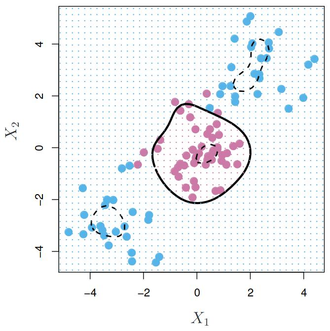

- La función de decisión puede representarse como:
  $$f(x) = \beta_0 + \sum_{i \in S} \hat{\alpha}_i K(x, x_i)$$
- El espacio de características implícito es de dimensión muy alta.
- Se controla la varianza al reducir drásticamente la mayoría de las dimensiones.

## SVM vs Regresión Logística

Con $f(X) = \beta_0 + \beta_1 X_1 + \dots + \beta_p X_p$, se puede reformular la optimización del clasificador de vectores de soporte como:
$$\min_{\beta_0, \beta_1, \dots, \beta_p}
\left\{ \sum_{i=1}^n \max \left[ 0, 1 - y_i f(x_i) \right] + \lambda \sum_{j=1}^p \beta_j^2 \right\}.$$

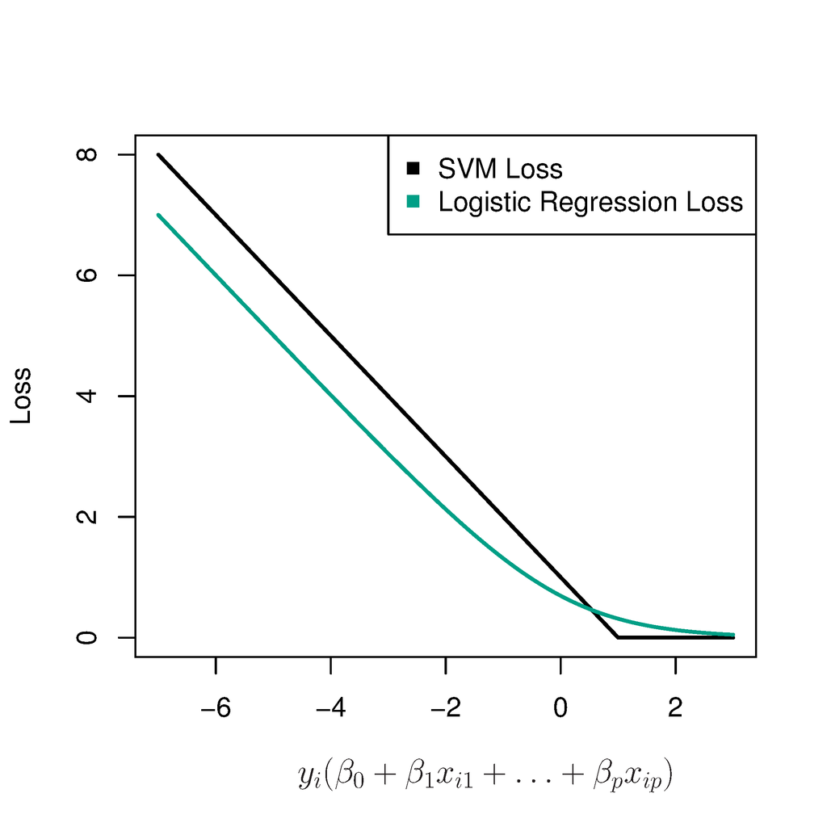

Esto tiene la forma de pérdida más penalización.

- La pérdida se conoce como pérdida de bisagra (*hinge loss*).
- Es muy similar a la “pérdida” en la regresión logística (log-verosimilitud negativa).

## Comparación entre SVM, LR y LDA

- Cuando las clases son (casi) separables, SVM funciona mejor que la Regresión Logística (LR) . Lo mismo ocurre con LDA (Análisis Discriminante Lineal).
- Cuando no lo son, la Regresión Logística (con penalización) y SVM son muy similares.
- Si se desea estimar probabilidades, la Regresión Logística es la opción.
- Para fronteras no lineales, los SVM con núcleos (kernel SVMs) son populares.